# friendsUp Exploration

Raphael Riege

2022-01-18

## Project description

In this project I will explore datasets containing profile and action data about users of the app [friendsUp](https://www.friendsup.de/). friendsUp is a network for women who are looking for friends. Each user creates a profile with essential information like interests and age. In the app, users can be contacted via Cheers (similar to a Like) or message. Since there is sensitive data in the raw data, only a report with aggregated data is presented. I gained access through the DecarbFriends project at the University of Kassel, which cooperates with friendsUp. The analysis period is from May 2016 to June 2021. The number of users during this time is 94,873.  
The project has the following objectives:

1. Find out how the number of (active) users develops over time.
2. Visualize the age distribution of users and find out if age is related to the number of cheers received.
3. A correlation analysis between the number of contact requests sent and the number of contact requests received.
4. Visualize the distribution of interests.
5. Visualize the geographical distribution of the users.

The goals of the study are, on the one hand, to gain an overview of the profiles and their behavior and, on the other hand, to derive potentials.

## Data Preprocess

```r
options(scipen = 999)

library(tidyverse)
library(rjson)
library(ggpubr)
library(grid)
library(gridExtra)
library(ggExtra)
library(rnaturalearth)
library(sf)
```

For the analysis 4 data sets are imported:

1. A data set with essential user information.
2. A dataset with the geographical locations of the users.
3. A dataset with all Cheers sent on friendsUp.
4. A dataset with all messages sent on friendsUp.

```r
user <- rjson::fromJSON(file = "../data/tidy_data/user.json")
coordinates <- read_csv("../data/tidy_data/coordinates.csv", col_types = "dcddcc")
cheers <- read_csv("../data/tidy_data/likes.csv", col_types = "dcc")
messages <- read_csv("../data/tidy_data/messages.csv", col_types = "dcc")
```

During data preparation, the different data sets are merged. First, I merge the user dataset with the coordinate dataset using a LocationID. I convert the timestamps about the first and last action of the users into a date-time format. I encode the users’ interests (tags) using one-hot encoding, since they are stored in a contiguous string. Lastly, I merge the number of cheers and messages received and sent with the user data using the userID.

```r
# user coords -------------------------------------------------------------

user_coords <- user %>% map('lastCoordinate') %>% map('id')
user_coords[sapply(user_coords, is.null)] <- NA
user_coords <- unlist(user_coords)

user_id <- user %>% map_chr('id')

user_df <- tibble(id = user_id,
                  coords = user_coords) %>%
  left_join(coordinates %>% select(coords = id, latitude, longitude))


# user profile ------------------------------------------------------------

user_df$age <- user %>% map_chr('age') %>% as.integer()

user_df$timestampLastOnline <- user %>% map_chr("timestampLastOnline") %>%
  as.double() %>%
  magrittr::divide_by(1000) %>%
  as.POSIXct(origin = "1970-01-01")
user_df$timestampReg <- user %>% map_chr("timestamp") %>%
  as.double() %>%
  magrittr::divide_by(1000) %>%
  as.POSIXct(origin = "1970-01-01")

user_df$active <- user_df$timestampLastOnline > as.POSIXct("2021-04-17")
user_df$lom <- format(user_df$timestampLastOnline, "%Y-%m")
user_df$fom <- format(user_df$timestampReg, "%Y-%m")
user_df$used <- !is.na(user_df$coords)

## tags one-hot
tags <- map(user, "tags")
tags[sapply(tags, is.null)] <- NA
tags_options <- tags %>% unlist() %>%  unique() %>% na.omit() %>% as.character()
contains_tags <- function(id){
  tags_options %in% tags[[id]]
}
tags_df <- map(1:nrow(user_df), contains_tags)
tags_df <- do.call("rbind", tags_df)
colnames(tags_df) <- tags_options

tags_df <- cbind(user_id, tags_df) %>% as_tibble()

# cheers ------------------------------------------------------------------

sendCheers <- cheers %>% count(User) %>% rename("sendCheers" = "n")
receivedCheers <- cheers %>% count(LikeUser) %>% rename("receivedCheers"= "n")

user_df <-
  user_df %>% left_join(sendCheers, by = c("id" = "User")) %>%
  left_join(receivedCheers, by = c("id" = "LikeUser"))

# messages ----------------------------------------------------------------

sendMessages <- messages  %>% count(fromUser) %>% rename("sendMessages" = "n")
receivedMessages <- messages %>% count(toUser) %>% rename("receivedMessages"= "n")

user_df <-
  user_df %>% left_join(sendMessages, by = c("id" = "fromUser")) %>%
  left_join(receivedMessages, by = c("id" = "toUser"))
```

## Data Visualization

### 1. First and last actions

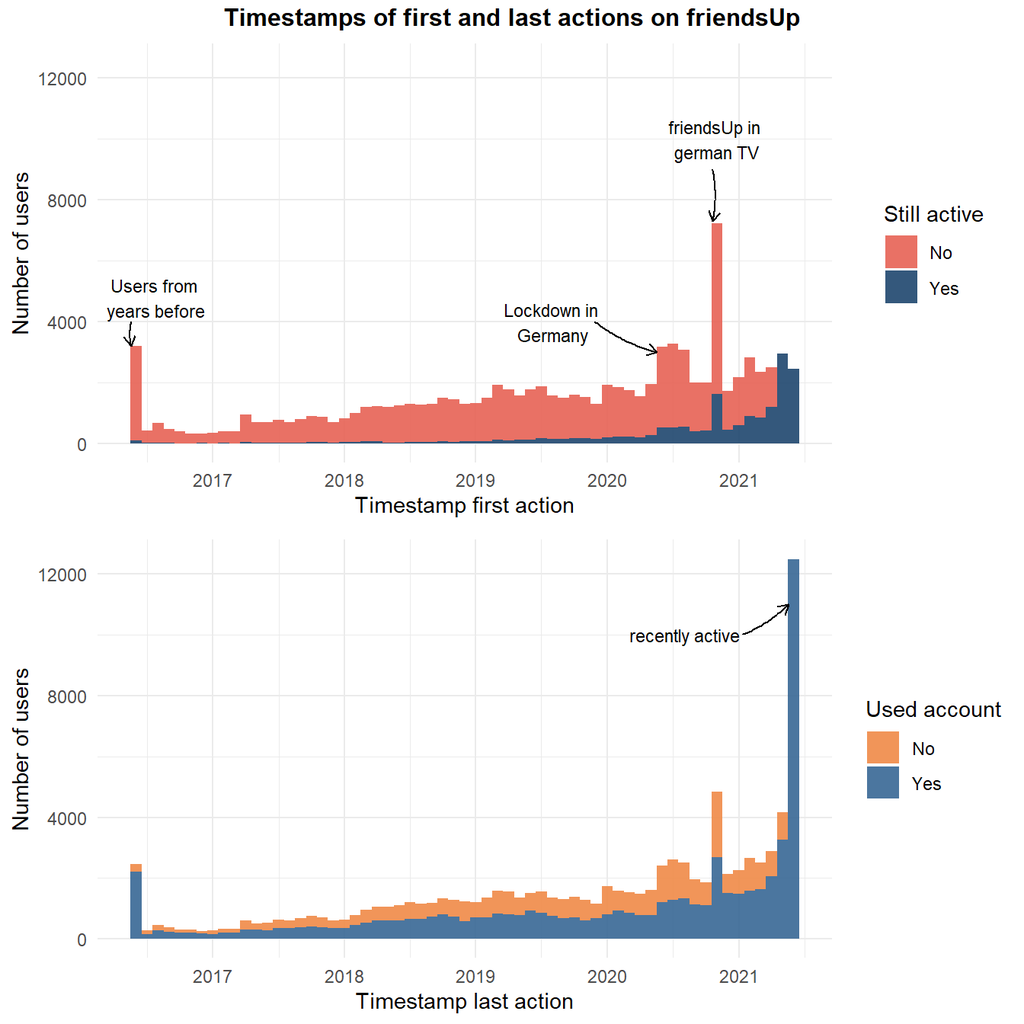

```r
first_actions <-
  user_df %>%
  ggplot(aes(x = timestampReg, fill = active)) +
  geom_histogram(binwidth = 2629800, alpha = 0.9) +
  scale_x_datetime(date_breaks = "1 year", date_labels = "%Y") +
  scale_fill_manual(values = c("#e76254", "#1e466e"),
                    labels = c("No", "Yes")) +
  annotate(
    geom = "curve", x = user_df$timestampReg %>% min(),
    y = 4000, xend =  user_df$timestampReg %>% min(), yend = 3200,
    curvature = .1, arrow = arrow(length = unit(2, "mm"))
  ) +
  annotate(geom = "text", size = 3,
           x = user_df$timestampReg %>% min() + 6000000,
           y = 4800,
           label = "Users from \nyears before") +
  annotate(
    geom = "curve", x = as.POSIXct("2020-11-01")  - 1000000,
    y = 9000, xend =  as.POSIXct("2020-11-01") - 1000000, yend = 7300,
    curvature = -.1, arrow = arrow(length = unit(2, "mm"))
  ) +
  annotate(geom = "text", size = 3,
           x = as.POSIXct("2020-11-01") ,
           y = 10000,
           label = "friendsUp in \ngerman TV") +
  annotate(
    geom = "curve", x = as.POSIXct("2020-03-22")  - 10000000,
    y = 4000, xend =  as.POSIXct("2020-03-22") + 5000000, yend = 3000,
    curvature = .1, arrow = arrow(length = unit(2, "mm"))
  ) +
  annotate(geom = "text", size = 3,
           x = as.POSIXct("2020-01-01") - 13000000,
           y = 4000,
           label = "Lockdown in \nGermany") +
  labs(y = "Number of users", x = "Timestamp first action", fill = "Still active") +
  theme_minimal() +
  ylim(0, 12500)


last_actions <-
  user_df %>%
  ggplot(aes(x = timestampLastOnline, fill = used)) +
  geom_histogram(binwidth = 2629800, alpha = 0.9)+
  scale_fill_manual(values = c("#ef8a47", "#376795"),
                    labels = c("No", "Yes")) +
  annotate(
    geom = "curve", x = as.POSIXct("2021-03-22")  - 6000000,
    y = 10000, xend =  as.POSIXct("2021-03-22") + 5000000, yend = 11000,
    curvature = .1, arrow = arrow(length = unit(2, "mm"))
  ) +
  annotate(geom = "text", size = 3,
           x = as.POSIXct("2021-01-01") - 13000000,
           y = 10000,
           label = "recently active") +
  labs(y = "Number of users", x = "Timestamp last action", fill = "Used account") +
  theme_minimal() +
  ylim(0, 12500)

grid.arrange(
  rbind(ggplotGrob(first_actions), ggplotGrob(last_actions), size = "last"),
  top = grid::textGrob("Timestamps of first and last actions on friendsUp",
                       gp = gpar(fontface = "bold"))
)
```

It can be seen that first-time actions tend to increase, but to a lesser extent, last-time actions also increase. It can be concluded that the number of users is increasing, but the number of active users is increasing to a much lesser extent. The lockdown in Germany also seems to have increased the number of users. The increase in the number of first-time actions after friendsUp was shown on German TV is even more significant.  
The color grouping in the top chart also shows that the vast majority of users who had their first action before 2020 were no longer active by mid-2021. The bottom chart shows that almost half of the users who were active for the last time in a month never took a second action. It should therefore be worthwhile for friendsUp to find out why users no longer use the app or don’t even start using it.

### 2. User age

The purpose of the following graphic is to show the age distribution and whether there is a relationship between age and the number of cheers received. To do this, I combine a bar chart with a violin plot. I divide the age into age categories. The number of cheers received is logarithmized for better visibility.

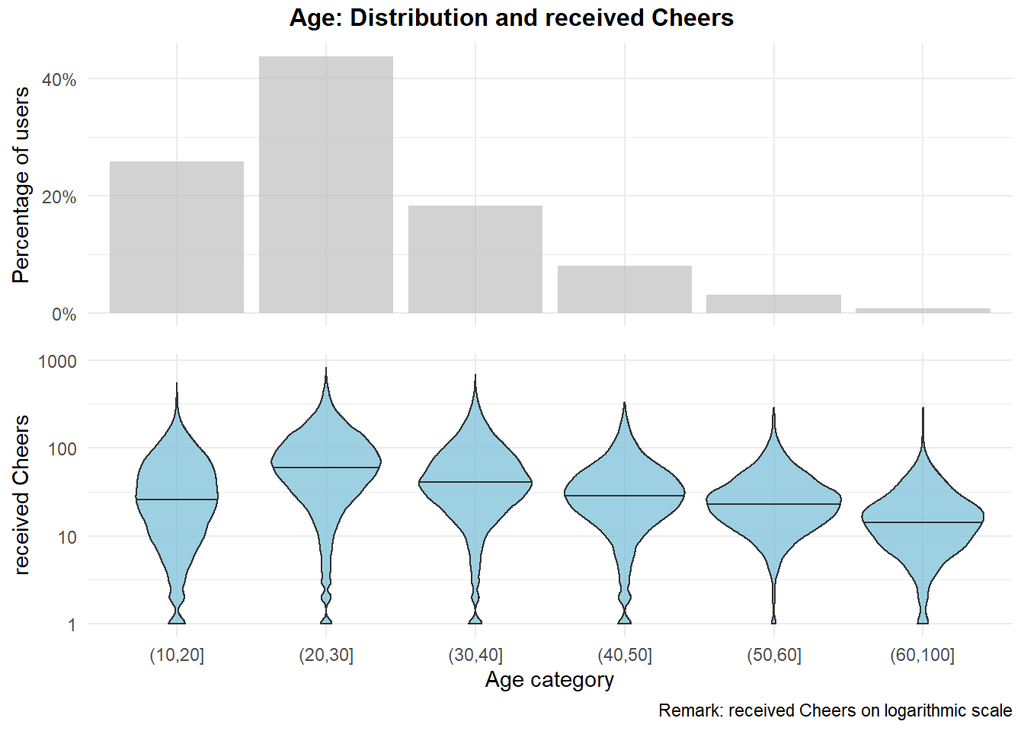

```r
user_df$age_cat <- user_df$age %>% cut(c(10, 20, 30, 40, 50, 60, 100))

violine <-
  ggplot(user_df %>% drop_na(age_cat), aes(x = age_cat, y = receivedCheers)) +
  geom_violin(draw_quantiles = c(.5), fill = "#72bcd5", alpha = 0.7) +
  theme_minimal() +
  scale_y_log10() +
  labs(x = "Age category", y = "received Cheers",
       caption = 'Remark: received Cheers on logarithmic scale')



dist <-
  user_df %>% drop_na(age_cat) %>%
  count(age_cat) %>%
  mutate(perc = n / sum(n)) %>%
  ggplot(aes(x = age_cat, y = perc)) +
  geom_col(fill = "grey", alpha = 0.7) +
  scale_y_continuous(breaks = seq(0, 0.4, 0.2),
                     labels = scales::percent_format(accuracy = 1)) +
  theme_minimal() +
  theme(
    axis.text.x=element_blank(),
    axis.title.x=element_blank(),
  ) +
  labs(y = "Percentage of users")





grid.arrange(
  rbind(ggplotGrob(dist), ggplotGrob(violine), size = "last"),
  top = grid::textGrob("Age: Distribution and received Cheers",
                       gp = gpar(fontface = "bold"))
)
```

The most strongly represented age group is the 20 to 30 year olds. Users over 40 are significantly less common. Approximately 70% of users are younger than 30. The group of users over 30 therefore still has a lot of room for improvement, especially in view of the fact that typical reorganization phases for women’s circles of friends often occur at a later stage in their lives. In addition, younger age groups seem to receive more Cheers than older age groups. This suggests that age groups that are less frequently represented also receive fewer Cheers individually, which is another reason for improving the app’s appeal to older age groups.

### 3. Cheers and messages

The following graphic is divided into two scatterplots. The left side contains the number of cheers of the users and the right side contains the number of messages. The X-axes show the number of cheers and messages sent. The Y-axes show the received cheers and messages. The orange line indicates a 1:1 ratio. The blue line visualizes a smoothed function that is fitted to the actual sent/received ratio. Around the scatterplots, histograms represent the distribution of each variable. Outliers with values over 1,000 are excluded.

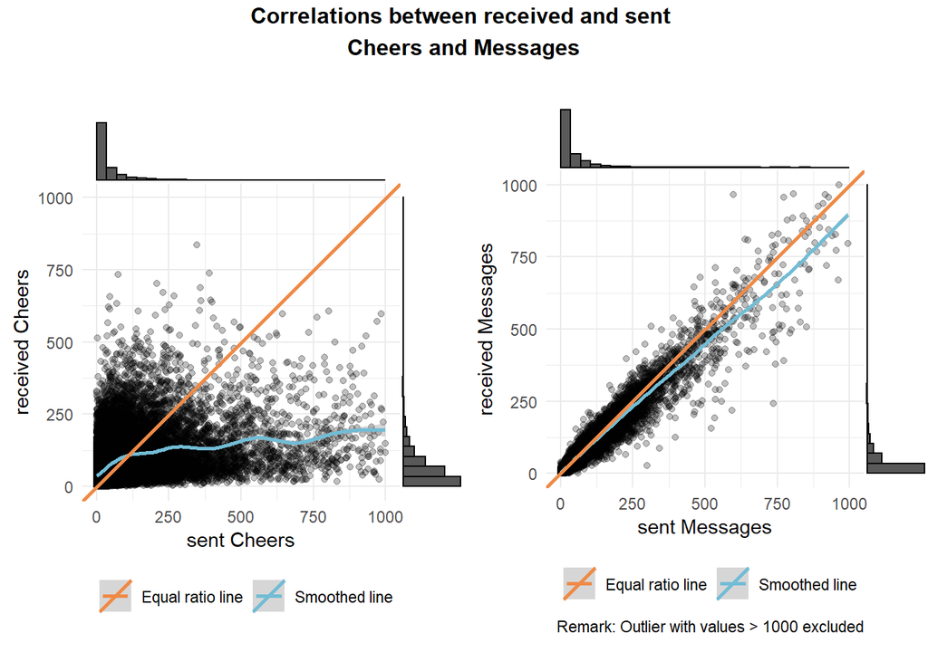

```r
cheers <-
  ggplot(user_df, aes(x = sendCheers, y = receivedCheers)) +
  geom_point(alpha = 0.25) +
  geom_smooth(aes(colour="Smoothed line")) +
  lims(x = c(0, 1000),
       y = c(0, 1000)) +
  geom_abline(aes(slope=1, intercept=0, colour="Equal ratio line"), size=1) +
  scale_color_manual(name = "", values = c("#ef8a47", "#72bcd5")) +
  coord_fixed(ratio = 1) +
  theme_minimal() +
  theme(legend.position="bottom") +
  labs(x = "sent Cheers", y = "received Cheers")

cheers <- ggMarginal(cheers, type = "histogram")


messages <-
  ggplot(user_df, aes(x = sendMessages, y = receivedMessages)) +
  geom_point(alpha = 0.25) +
  geom_smooth(aes(colour="Smoothed line")) +
  lims(x = c(0, 1000),
       y = c(0, 1000)) +
  geom_abline(aes(slope=1, intercept=0, colour="Equal ratio line"), size=1) +
  scale_color_manual(name = "", values = c("#ef8a47", "#72bcd5")) +
  coord_fixed(ratio = 1) +
  theme_minimal() +
  theme(legend.position="bottom") +
  labs(x = "sent Messages", y = "received Messages",
       caption = 'Remark: Outlier with values > 1000 excluded')


messages <- ggMarginal(messages, type = "histogram")



annotate_figure(ggarrange(cheers, messages),
                top = text_grob("Correlations between received and sent \nCheers and Messages\n",
                                face = "bold", size = 12))
```

Cheers and Messages are all right-skewed. This means that a large number of users have sent and received a small number of cheers and messages, and a small number of users have received and sent a large number of messages and cheers. The number of Cheers received correlates positively with the number of Cheers sent. In the lower range, where there are very many users, the number of received cheers is higher than the number of sent cheers. In the upper range, however, this ratio drops significantly and the number of received cheers increases only slightly with the number of sent cheers. This is different for messages. Here, the actual ratio is nearly linear that is slightly below the equal ratio line. The correlation is therefore close to one. The number of messages received is therefore presumably more strongly related to the number of messages sent, since sent messages are more often followed by the same number of replies. This is not necessarily the case with Cheers.

### 4. Tags

Now I explore the stated tags, which reflect interests. A bar chart should indicate the percentage of profiles that contain the corresponding tag.

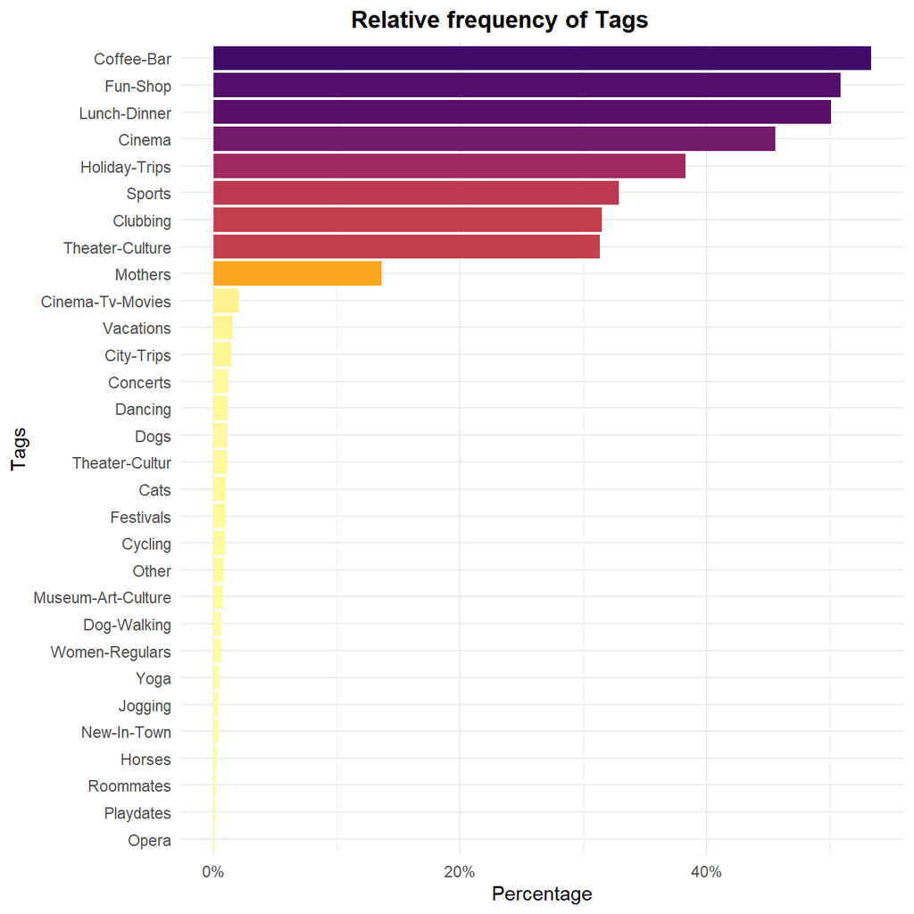

```r
tags_df %>% select(-user_id) %>% mutate_all(as.logical) %>% colSums() %>%
  enframe() %>% mutate(perc = value / nrow(tags_df), name = name %>% str_to_title()) %>%
  ggplot(aes(x = reorder(name, perc), y = perc, fill = -perc)) +
  geom_col() +
  scale_y_continuous(labels = scales::percent) +
  scale_fill_viridis_c(option = "B", guide = "none", begin = 0.2) +
  coord_flip() +
  labs(title = "Relative frequency of Tags",
       x = "Tags", y = "Percentage") +
  theme_minimal()  +
  theme(plot.title = element_text(hjust = 0.4, face = "bold"))
```

### 5. Geographical distribution

Lastly, I would like to visualize the geographic distribution of users. For this I use the map of the DACH region and plot a point for each user according to the coordinates of his last login.

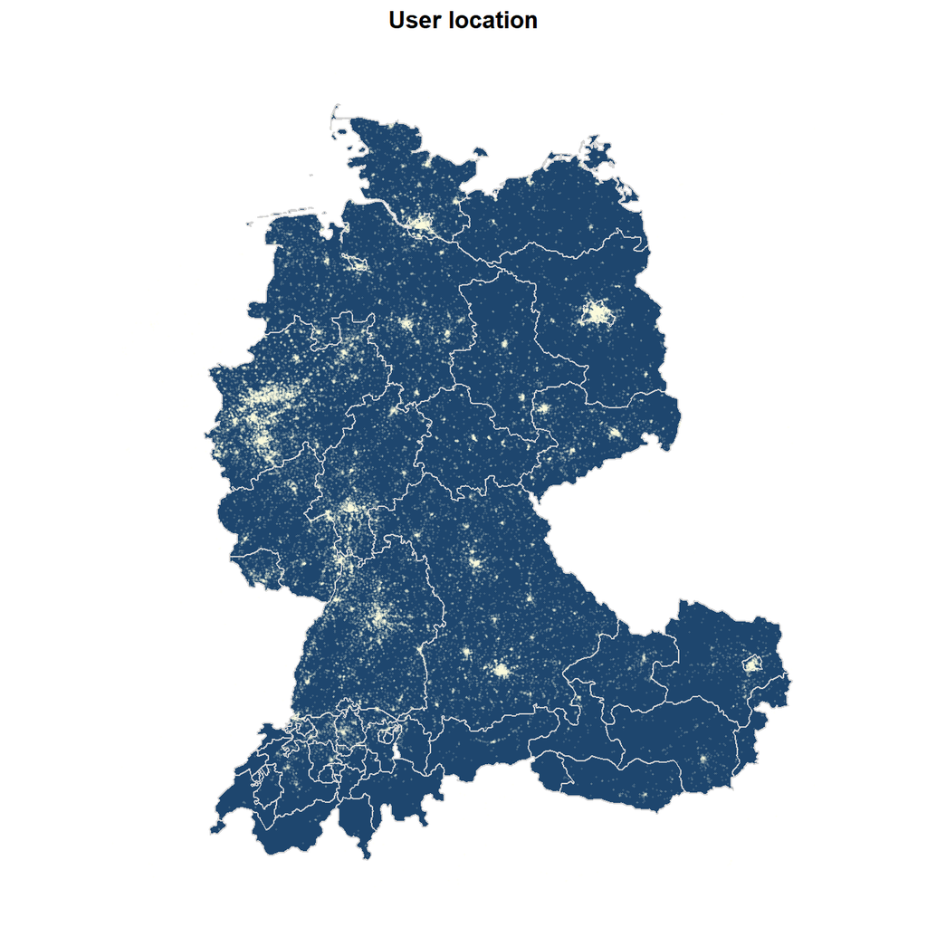

```r
dach <- ne_states(
  country = c("Germany", "Austria", "Switzerland"),
  returnclass = "sf"
)

coords.data <- user_df %>%
  select(Latitude = latitude, Longitude = longitude) %>%
  drop_na(Longitude)

ggplot() +
  geom_sf(data=dach, fill = "#1e466e", color = 'lightgrey') +
  geom_point(data = coords.data %>% filter(Latitude > 45.5, Latitude < 55.5, Longitude > 4, Longitude < 18),
             mapping = aes(x = Longitude, y = Latitude),
             size = 0.2, alpha = 0.1, color = "lightyellow") +

  theme_void() +
  ggtitle("User location") +
  theme(plot.title = element_text(hjust = 0.5, face = "bold"))
```

Most users are in Germany’s metropolitan areas and larger cities. Use of the app is particularly well established in the Ruhr region. However, there is no region in Germany where there is no user. The data therefore shows good coverage of the DACH region, but this could still be greatly expanded, especially in rural areas.